# Video evaluation via SoSci

Irene Sophia Plank

2022-10-05

# Setup

The data is loaded and relevant columns are selected. Then, it is transformed to the long format and the Video names are added. In the end, all information is contained in one data frame that is in the long format.

# Choosing videos for the FER task

```r
# get rid of extreme outliers for each video
df_fil = df %>% group_by(VID, FID, GEN) %>%
  filter(NAT > quantile(NAT, na.rm = T)[2] - 1.5*IQR(NAT, na.rm = T))

# aggregate per face ID and emotion
df_agg = df_fil %>% group_by(VID, GEN, EMO) %>%
  summarise(
    NAT_med = median(NAT, na.rm = T),
    NAT_min = min(NAT, na.rm = T),
    NAT_val = n()
  ) %>% filter(NAT_med >= 50 & NAT_val > 10)
# choose the videos with the highest minima
n = 8 # number of videos per gender and emotion
vid_sel = df_agg %>%
  arrange(desc(NAT_min)) %>%
  group_by(GEN, EMO) %>%
  slice(1:n) %>%
  select(GEN, EMO, VID)

# filter the full data frame to only include selected videos
df_FER_sel = df_fil %>% filter(VID %in% vid_sel$VID)

# aggregate info for the selected videos
df_FER_sel_agg = df_FER_sel %>% group_by(FID, VID, EMO, GEN) %>%
  summarise(
    NAT_avg = mean(NAT, na.rm = T),
    NAT_ste = sd(NAT, na.rm = T) / sqrt(n()),
    NAT_med = median(NAT, na.rm = T),
    NAT_min = min(NAT, na.rm = T)
  ) %>%
  arrange(FID, EMO, VID)
kable(df_FER_sel_agg)
```

| FID | VID | EMO | GEN | NAT_avg | NAT_ste | NAT_med | NAT_min |
| --- | --- | --- | --- | --- | --- | --- | --- |
| F01 | AF01AFS_gimped | AF | F | 65.48000 | 4.679430 | 65.0 | 30 |
| F01 | AF01ANS_gimped | AN | F | 80.08696 | 4.076789 | 85.0 | 37 |
| F01 | AF01HAS_gimped | HA | F | 70.14286 | 4.723440 | 74.0 | 27 |
| F01 | AF01SAS_gimped | SA | F | 65.40000 | 5.216640 | 66.0 | 21 |
| F02 | AF02AFS_gimped | AF | F | 78.96000 | 3.592344 | 81.0 | 41 |
| F02 | BF02HAS_gimped | HA | F | 82.81250 | 4.041677 | 84.5 | 46 |
| F02 | AF02SAS_gimped | SA | F | 60.78947 | 5.372977 | 65.0 | 27 |
| F05 | AF05AFS_gimped | AF | F | 74.84000 | 4.412361 | 81.0 | 25 |
| F05 | AF05ANS_gimped | AN | F | 65.60000 | 4.720876 | 63.0 | 21 |
| F05 | AF05HAS_gimped | HA | F | 72.09091 | 3.921254 | 74.5 | 21 |
| F05 | AF05SAS_gimped | SA | F | 69.69565 | 4.852950 | 72.0 | 21 |
| F07 | BF07ANS_gimped | AN | F | 65.56000 | 4.519248 | 68.0 | 21 |
| F07 | BF07SAS_gimped | SA | F | 64.12000 | 4.836776 | 61.0 | 25 |
| F08 | BF08HAS_gimped | HA | F | 73.52381 | 3.566791 | 76.0 | 31 |
| F09 | AF09AFS_gimped | AF | F | 74.92308 | 7.346254 | 83.0 | 23 |
| F09 | AF09HAS_gimped | HA | F | 70.04000 | 5.441960 | 81.0 | 10 |
| F09 | AF09SAS_gimped | SA | F | 79.50000 | 3.979112 | 86.0 | 38 |
| F11 | AF11SAS_gimped | SA | F | 65.32000 | 5.179356 | 68.0 | 25 |
| F14 | AF14ANS_gimped | AN | F | 63.52000 | 5.400654 | 63.0 | 26 |
| F14 | AF14SAS_gimped | SA | F | 72.68000 | 4.248027 | 74.0 | 37 |
| F16 | AF16AFS_gimped | AF | F | 63.76000 | 5.407489 | 75.0 | 26 |
| F16 | AF16HAS_gimped | HA | F | 58.87500 | 5.785199 | 63.5 | 11 |
| F19 | AF19HAS_gimped | HA | F | 63.40000 | 6.081940 | 73.0 | 10 |
| F20 | AF20AFS_gimped | AF | F | 70.50000 | 5.208341 | 77.5 | 22 |
| F20 | AF20ANS_gimped | AN | F | 71.36000 | 4.116989 | 69.0 | 30 |
| F20 | AF20SAS_gimped | SA | F | 66.12000 | 4.294306 | 70.0 | 25 |
| F24 | AF24AFS_gimped | AF | F | 61.04167 | 5.294747 | 60.0 | 25 |
| F24 | AF24ANS_gimped | AN | F | 73.52000 | 4.004214 | 78.0 | 31 |
| F29 | AF29AFS_gimped | AF | F | 68.04000 | 4.747448 | 69.0 | 28 |
| F29 | AF29ANS_gimped | AN | F | 64.76000 | 5.172775 | 66.0 | 18 |
| F29 | AF29HAS_gimped | HA | F | 66.24000 | 4.966313 | 75.0 | 17 |
| F32 | AF32ANS_gimped | AN | F | 69.92000 | 4.535754 | 77.0 | 25 |
| M01 | AM01AFS_gimped | AF | M | 73.40000 | 4.277481 | 72.5 | 34 |
| M01 | AM01ANS_gimped | AN | M | 79.05882 | 3.203250 | 76.0 | 56 |
| M01 | AM01SAS_gimped | SA | M | 67.27778 | 5.642281 | 71.5 | 21 |
| M02 | AM02ANS_gimped | AN | M | 64.80952 | 5.251584 | 63.0 | 22 |
| M02 | AM02HAS_gimped | HA | M | 76.05263 | 3.561879 | 75.0 | 55 |
| M03 | AM03AFS_gimped | AF | M | 71.33333 | 4.703764 | 71.0 | 29 |
| M03 | AM03SAS_gimped | SA | M | 69.75000 | 4.561207 | 68.0 | 30 |
| M05 | AM05AFS_gimped | AF | M | 70.61905 | 4.419910 | 75.0 | 34 |
| M05 | AM05ANS_gimped | AN | M | 59.80952 | 5.367281 | 56.0 | 16 |
| M06 | AM06SAS_gimped | SA | M | 65.95238 | 5.105308 | 73.0 | 23 |
| M07 | AM07AFS_gimped | AF | M | 66.38095 | 5.654108 | 69.0 | 21 |
| M07 | AM07SAS_gimped | SA | M | 63.52381 | 4.332391 | 65.0 | 27 |
| M09 | AM09HAS_gimped | HA | M | 85.35294 | 2.400890 | 84.0 | 64 |
| M09 | AM09SAS_gimped | SA | M | 77.70000 | 3.935065 | 80.5 | 40 |
| M10 | AM10AFS_gimped | AF | M | 74.76190 | 5.085415 | 86.0 | 36 |
| M10 | AM10HAS_gimped | HA | M | 82.72222 | 3.545968 | 83.5 | 46 |
| M11 | AM11AFS_gimped | AF | M | 74.47619 | 4.552142 | 78.0 | 33 |
| M11 | AM11ANS_gimped | AN | M | 79.00000 | 3.277515 | 80.5 | 46 |
| M11 | AM11HAS_gimped | HA | M | 79.94444 | 3.257442 | 79.0 | 60 |
| M13 | AM13AFS_gimped | AF | M | 73.60000 | 4.660811 | 81.0 | 30 |
| M13 | AM13HAS_gimped | HA | M | 79.42857 | 4.060009 | 82.0 | 31 |
| M13 | AM13SAS_gimped | SA | M | 67.14286 | 5.033358 | 78.0 | 23 |
| M14 | AM14ANS_gimped | AN | M | 76.85714 | 4.398747 | 79.0 | 35 |
| M14 | AM14HAS_gimped | HA | M | 76.04762 | 4.027569 | 76.0 | 42 |
| M14 | AM14SAS_gimped | SA | M | 72.57143 | 5.222466 | 74.0 | 21 |
| M23 | BM23ANS_gimped | AN | M | 55.85714 | 6.508707 | 63.0 | 12 |
| M23 | BM23SAS_gimped | SA | M | 57.28571 | 5.424435 | 63.0 | 19 |
| M27 | BM27HAS_gimped | HA | M | 66.33333 | 4.939796 | 65.0 | 22 |
| M28 | BM28ANS_gimped | AN | M | 69.25000 | 4.566396 | 73.5 | 25 |
| M28 | BM28HAS_gimped | HA | M | 78.33333 | 3.699496 | 79.0 | 41 |
| M31 | BM31AFS_gimped | AF | M | 73.60000 | 4.718608 | 73.5 | 32 |
| M31 | BM31ANS_gimped | AN | M | 71.00000 | 5.366127 | 78.0 | 23 |

```r
# # get all comments
# df_FER_sel_COM = df_FER_sel %>% filter(!is.na(COM)) %>% select(GEN, FID, VID, COM) %>%
#   arrange(FID, VID)
# kable(df_FER_sel_COM)

# drop all unnecessary variables
rm(list = setdiff(ls(), c("df", "df_FER_sel", "df_FER_sel_agg", "df_FER_sel_COM")))
```

## Visualisation

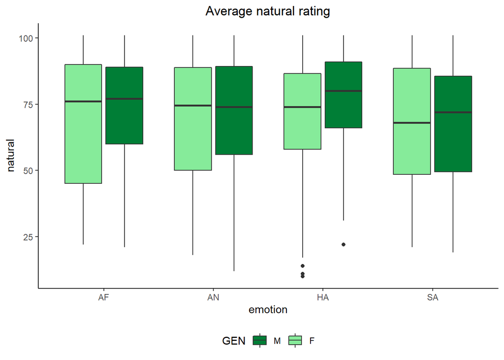

```r
# set colour scheme
cls = c("#007e36", "#86eb9a")
names(cls) = c("M", "F")

# create boxplots
ggplot(df_FER_sel, aes(x = EMO, y = NAT, fill = GEN)) +
  geom_boxplot() +
  labs (x = "emotion", y = "natural") +
  ggtitle("Average natural rating") +
  theme_classic() + scale_fill_manual(values = cls) +
  theme(legend.position = "bottom", plot.title = element_text(hjust = 0.5))
```

A linear mixed model is computed to assess whether the four emotions of the selected videos are comparable in terms of natural ratings. Here, we use sum coding for the emotion and compare each emotion to the grand mean of all of them. This is explained more clearly on [CrossValidated](https://stats.stackexchange.com/questions/320740/how-to-interpret-sum-contrast-in-regression-lmm):

> `contr.sum` makes sure all the contrasts sum to zero so that the “intercept” term is the grand mean. The effects are summarized with coefficients representing the number of factor levels ($k$) minus 1. In this case, the last level is dropped. The coefficients represent a mean difference from the “grand mean” for the first $k−1$ factor levels.

> If you fit `lm(y ~ x - 1)` where $x$ has the sum contrast, then the model coefficients are the stratum specific means for each level of $x$, but the inference tests a mean difference from 0 for each level of $x$. This is useless unless $x$ [!sic?] is centered. I suggest you fit this model if you wish to simultaneously test the 3 parameters’ difference from the grand mean. Technically speaking, this is overkill since such a model is overspecified, but that isn’t inherently a bad thing.

```r
# center naturalnes
df_FER_sel$NAT = scale(df_FER_sel$NAT, scale = F)

# set factors correctly
df_FER_sel$EMO = as.factor(df_FER_sel$EMO)
contrasts(df_FER_sel$EMO)  = contr.Sum(levels(df_FER_sel$EMO))

# model -> each level of EMO separately? why?
m1 = lmer(formula = NAT ~ EMO - 1 + # fixed effects
                         (1 | CASE) + (1 | VID), # random effects
                         data = df_FER_sel, REML = T)

tab_model(m1, show.df = F, show.stat = T, show.ci = F, linebreak = F, wrap.labels = 80)
```

|  | NAT |  |  |
| --- | --- | --- | --- |
| Predictors | Estimates | Statistic | p |
| EMO [AF] | 0.80 | 0.29 | 0.772 |
| EMO [AN] | -1.21 | -0.44 | 0.661 |
| EMO [HA] | 2.91 | 1.05 | 0.295 |
| EMO [SA] | -2.06 | -0.74 | 0.458 |
| Random Effects |  |  |  |
| σ<sup>2</sup> | 248.76 |  |  |
| τ<sub>00</sub> <sub>VID</sub> | 24.93 |  |  |
| τ<sub>00</sub> <sub>CASE</sub> | 247.97 |  |  |
| ICC | 0.52 |  |  |
| N <sub>CASE</sub> | 46 |  |  |
| N <sub>VID</sub> | 64 |  |  |
| Observations | 1395 |  |  |
| Marginal R<sup>2</sup> / Conditional R<sup>2</sup> | 0.007 / 0.526 |  |  |

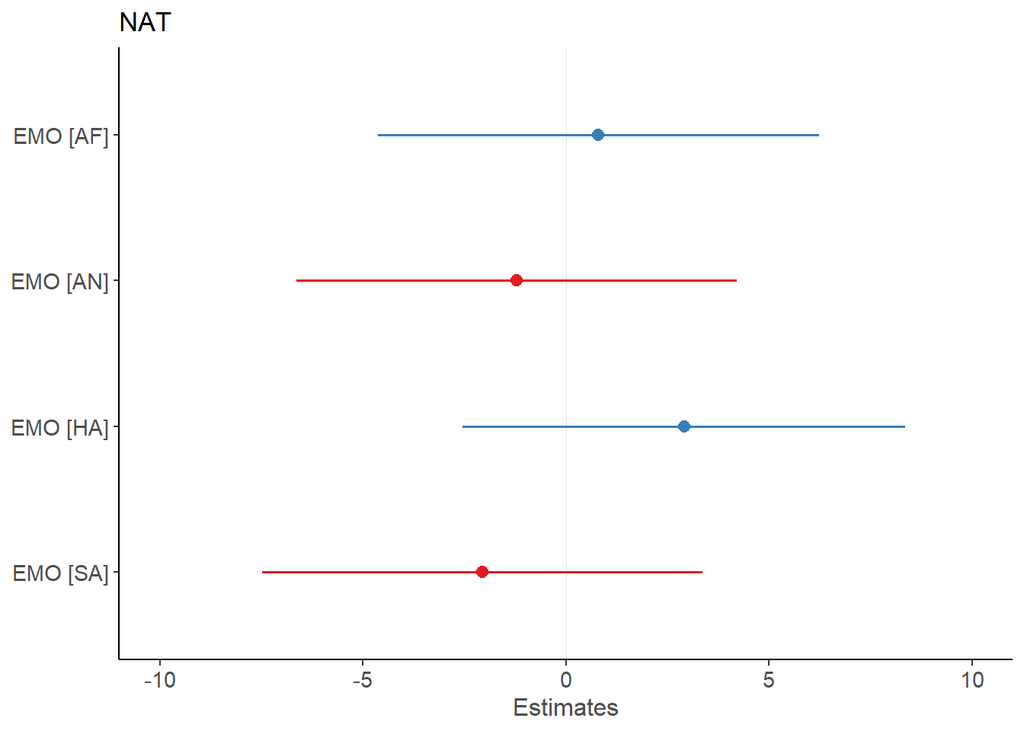

```r
set_theme(base = theme_classic())

plot_model(m1)
```

# Choosing videos for the PAL task

Since in the PAL task, we do not use the videos themselves but three stills of different emotion strengths, we can simply choose the videos with the best median natural ratings. However, to keep it consistent with the Lawson et al. (2017) paper, we will use six identities which are shown in each emotion.

```r
# get rid of extreme outliers for each video
df_fil = df %>% group_by(VID, FID, GEN) %>%
  filter(NAT > quantile(NAT, na.rm = T)[2] - 1.5*IQR(NAT, na.rm = T))

# aggregate per face ID and emotion
df_agg = df_fil %>% group_by(VID, FID, GEN, EMO) %>%
  summarise(
    NAT_med = median(NAT, na.rm = T)
  ) %>% filter(VID %in% df_FER_sel_agg$VID & (EMO == "AF" | EMO == "HA"))
# find out of which IDs both emotions are left
fids = df_agg$FID[duplicated(df_agg$FID)]
df_agg = df_agg %>% filter(FID %in% fids)

# choose the videos with the highest median
n = 3 # number of videos per gender and emotion
fid_sel = df_agg %>% group_by(GEN, FID) %>%
  summarise(NAT_med = mean(NAT_med)) %>%
  arrange(desc(NAT_med)) %>%
  group_by(GEN) %>%
  slice(1:n) %>%
  select(GEN, FID)
# filter the full data frame to only include selected videos
df_PAL_sel = df_fil %>% filter(FID %in% fid_sel$FID & (EMO == "AF" | EMO == "HA"))

# aggregate info for the selected videos
df_PAL_sel_agg = df_PAL_sel %>% group_by(FID, VID, EMO, GEN) %>%
  summarise(
    NAT_avg = mean(NAT, na.rm = T),
    NAT_ste = sd(NAT, na.rm = T) / sqrt(n()),
    NAT_med = median(NAT, na.rm = T),
    NAT_min = min(NAT, na.rm = T)
  ) %>%
  arrange(FID, EMO, VID)
kable(df_PAL_sel_agg)
```

| FID | VID | EMO | GEN | NAT_avg | NAT_ste | NAT_med | NAT_min |
| --- | --- | --- | --- | --- | --- | --- | --- |
| F02 | AF02AFS_gimped | AF | F | 78.96000 | 3.592344 | 81.0 | 41 |
| F02 | BF02HAS_gimped | HA | F | 82.81250 | 4.041677 | 84.5 | 46 |
| F05 | AF05AFS_gimped | AF | F | 74.84000 | 4.412361 | 81.0 | 25 |
| F05 | AF05HAS_gimped | HA | F | 72.09091 | 3.921254 | 74.5 | 21 |
| F09 | AF09AFS_gimped | AF | F | 74.92308 | 7.346254 | 83.0 | 23 |
| F09 | AF09HAS_gimped | HA | F | 70.04000 | 5.441960 | 81.0 | 10 |
| M10 | AM10AFS_gimped | AF | M | 74.76190 | 5.085415 | 86.0 | 36 |
| M10 | AM10HAS_gimped | HA | M | 82.72222 | 3.545968 | 83.5 | 46 |
| M11 | AM11AFS_gimped | AF | M | 74.47619 | 4.552142 | 78.0 | 33 |
| M11 | AM11HAS_gimped | HA | M | 79.94444 | 3.257442 | 79.0 | 60 |
| M13 | AM13AFS_gimped | AF | M | 73.60000 | 4.660811 | 81.0 | 30 |
| M13 | AM13HAS_gimped | HA | M | 79.42857 | 4.060009 | 82.0 | 31 |

```r
# # get all comments
# df_PAL_sel_COM = df_PAL_sel %>% filter(!is.na(COM)) %>% select(GEN, FID, VID, COM) %>%
#   arrange(FID, VID)
# kable(df_PAL_sel_COM)
```

## Visualisation

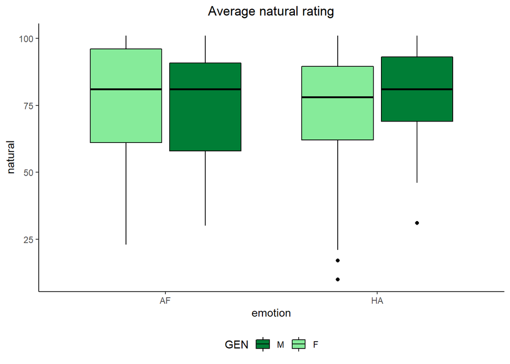

```r
# create boxplots
ggplot(df_PAL_sel, aes(x = EMO, y = NAT, fill = GEN)) +
  geom_boxplot() +
  labs (x = "emotion", y = "natural") +
  ggtitle("Average natural rating") +
  theme_classic() + scale_fill_manual(values = cls) +
  theme(legend.position = "bottom", plot.title = element_text(hjust = 0.5))
```

The same linear mixed model is computed to assess whether the two emotions of the selected videos are comparable in terms of natural ratings.

```r
# center naturalnes
df_PAL_sel$NAT = scale(df_PAL_sel$NAT, scale = F)

# set factors correctly
df_PAL_sel$EMO = as.factor(df_PAL_sel$EMO)
contrasts(df_PAL_sel$EMO)  = contr.Sum(levels(df_PAL_sel$EMO))

# model -> each level of EMO separately? why?
m2 = lmer(formula = NAT ~ EMO - 1 + # fixed effects
                         (1 | CASE) + (1 | VID), # random effects
                         data = df_PAL_sel, REML = T)

tab_model(m2, show.df = F, show.stat = T, show.ci = F, linebreak = F, wrap.labels = 80)
```

|  | NAT |  |  |
| --- | --- | --- | --- |
| Predictors | Estimates | Statistic | p |
| EMO [AF] | -0.60 | -0.22 | 0.824 |
| EMO [HA] | 0.40 | 0.15 | 0.883 |
| Random Effects |  |  |  |
| σ<sup>2</sup> | 204.48 |  |  |
| τ<sub>00</sub> <sub>CASE</sub> | 209.94 |  |  |
| τ<sub>00</sub> <sub>VID</sub> | 6.02 |  |  |
| ICC | 0.51 |  |  |
| N <sub>CASE</sub> | 46 |  |  |
| N <sub>VID</sub> | 12 |  |  |
| Observations | 245 |  |  |
| Marginal R<sup>2</sup> / Conditional R<sup>2</sup> | 0.001 / 0.514 |  |  |

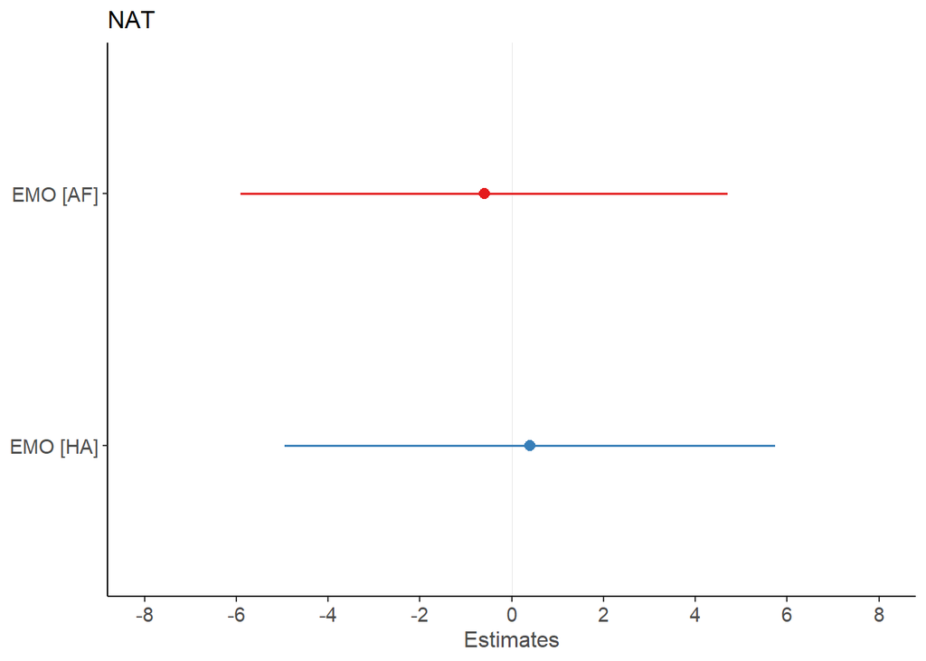

```r
plot_model(m2)
```